# Nest Provisioning in a Fire Disturbed Landscape

Eliza Stein

12/3/2020

# Introduction

Fire plays an important role as a consistent disturbance in maintaining open stands of old-growth Ponderosa Pine (*Pinus ponderosa*) forests by helping to eliminate understory and limit fuel loads (Veblen et al., 2000). Before human intervention, Ponderosa Pine forests naturally underwent forest fires in 5-50 year intervals (Veblen et al., 2000). Over the past century, however, tree planting initiatives and increased implementation of fire suppression have led to increased density of stands (Griffis et al., 2001), making forest stands that are already drought stressed even more susceptible to high severity crown fires (Veblen et al., 2000). In 2002, a human-caused wildfire, the Hayman Fire, burned 138,000 acres of old-growth Ponderosa Pine forests in Colorado’s Pike National Forest (Graham, 2003). It was classified as having “uncharacteristic stand-replacing severity,” and more than 96% of trees (mostly Ponderosa Pine and Douglas Fir) in the burn footprint did not survive (Fornwalt et al., 2016). About 50% of these trees were over 200 years old.

The Flammulated Owl (*Psiloscops flammeolus*) is a territorial, insectivorous, and nocturnal raptor native to Yellow Pine forests in portions of the Rocky Mountains, Sierra Nevada Mountains, and the Occidental Mountains (Linkhart & McCallum, 2013). The diet of the owl primarily consists of moths native to these regions (Linkhart & McCallum, 2013). As a highly specialized secondary cavity nesting raptor, the Flammulated Owl is deemed an indicator species. This species relies on old-growth mixed Yellow Pine forests for breeding and wintering habitats and primarily forages on foliage-gleaning moths (Reynolds & Linkhart, 1992). The Hayman Fire scar, which was previously dominated by prime Flammulated Owl habitat, continues to attract breeding individuals, but their success in this sub-optimal habitat is not well supported. Survival models show that annual adult Flammulated Owl survival in the Hayman Fire burn scar is currently lower for males than in a nearby control site, and adult annual survival in the burn scar appears to be decreasing each year following the fire (Yanco et al. unpublished data).

Here, I examine one possible explanation for decreased male survivorship in the Hayman Fire burn area: foraging ability. Observational data suggests that males are the primary nest provisioners throughout the breeding season, meaning that they could be suffereing from increased energy demands more thatn females. High severity burns dramatically alter vegetation structure, which in turn alters insect communities. Over time, insect communities within high intensity burn scars can crash, leaving avian predators without important food resources (Nappi et al., 2010). The Hayman Fire also resulted in the mortality of almost all trees in its path, particularly old-growth conifers (Fornwalt et al., 2016). Flammulated Owls have been shown to favor old-growth conifers for foraging in Colorado. According to one study, 80% of prey captures were in Ponderosa Pine or Douglas Fir trees, and the mean age of foraging trees was 199 years (compared to an overall forest mean of 111 years) (Reynolds & Linkhart, 1992). If Flammulated Owls are adapting their behavior in response to changing prey availlability or foraging site availability, I would expect that the rate of prey deliveries to active nests would differ between the Hayman Fire burn scar and nearby unburned sites (Zárybnická et al., 2009). If Flammulated Owls are not adapting their behavior, this could mean that prey availability has either not changed or, more likely, that Flammulated Owls, which have not historically occupied landscapes prone to high severity burns, do not adapt their behavior in response to large-scale landscape changes. This would make them highly sensitive to large-scale disturbances that affect foraging at important times, such as during the breeding season.

The objectives for this analysis are to examine:

1. How do prey delivery rates change throughout the night?
2. How do male and female nest provisioning strategies differ?
3. How is nest provisioning affected by high severity burns?

# Methods

## Analysis

First, average prey delivery rates for both males and females were compared at 15-minute intervals throughout the night. Any prey deliveries recorded at “Unknown” were discarded. Bootstrap confidence intervals were generated by sampling each time interval 1000 times, and means with CIs were visualized by plotting.

Then, the data was filtered to include only HFSA, our treatment area, and MGSA, an unburned study site ~5 miles from HFSA, with similar habitat. Means and bootstrap confidence intervals were plotted using the above technique.

# Initialization

All relative paths begin at the final-project/analysis subdirectory.

### Required Packages

```r
knitr::opts_chunk$set(message = FALSE)
```

```r
# Data manipulation and visualization
library(knitr)
library(tidyverse)
library(gridExtra)
library(tinytex)
tinytex::install_tinytex()

# Spatial data analysis
library(rgdal)
library(raster)
library(sf)
library(RColorBrewer)
```

### Custom functions

getCI is designed to generate bootstrap confidence intervals from a given vector.

```r
#' getCI
#'
#' @param vec a vector
#' @param n_samp number of times to sample data
#'
#' @return upper and lower bootstrap confidence intervals
#'
#'
#' @examples
#'    getCI(1:20, 2000)
#' @export

getCI <- function(vec, n_samp=1000) {
  smp <- replicate(n_samp, mean(sample(vec, replace = TRUE), na.rm = TRUE))
  CIs <-quantile(smp, c(0.025, 0.975), na.rm = T)
  return(CIs)
}
```

testNormality runs a Shapiro-Wilk test on each time interval in a pd data.frame and returns p values based on the null hypothesis that the data is normally distributed. If p < 0.05, data is not normally distributed.

```r
#' testNormality
#'
#' @param dat a data.frame where columns = time intervals and rows = # prey deliveries
#' @param margin.a margin for apply statement running shapiro.test. default = 2.
#'
#' @return vector of p.values for each column of dat
#'
#'
#' @examples
#'    testNormality(pdM_inc, 2)
#' @export

testNormality <- function(dat, margin = 2) {
  norms <- apply(dat, margin, FUN = shapiro.test)
  return(sapply(norms, function(x){x[["p.value"]]}))
}
```

testWilcox runs a Wilcoxon test on the nth columns of two different data.frames (i.e. df1[1] and df2[1], df1[2] and df2[2], etc.). We add the argument exact = FALSE to suppress the Warning message that exact p.values with ties can’t be computed (warning comes from assumption that values are continuous). This is useful in testing for difference between prey delivery observations at time = 15 in one study site and at time = 15 in a second study site, when the data are not normally distributed.

```r
#' testWilcox
#'
#' @param a a data.frame where columns = time intervals and rows = # prey deliveries
#' @param b a second data.frame where columns = time intervals and rows = # prey deliveries
#'
#' @return data.frame of p values (values) and corresponding time intervals (ind)
#'
#'
#' @examples
#'    testWilcox(pdMGSA_inc, pdHFSA_inc)
#' @export

testWilcox <- function(a, b){
  tmp <- mapply(wilcox.test, a, b, exact = FALSE)
  p.values <- stack(mapply(function(x, y) wilcox.test(x, y, exact = FALSE)$p.value, a, b))
  return(p.values)
}
```

# Study Area

The Hayman Fire Study Area (HFSA) is located in central Colorado, USA (Figure 1). Missouri Gulch Study Area (MGSA) is located 5 miles east of the eastern edge of the fire scar. 45 nests were observed in HFSA and MGSA between 2004 and 2020. A total of 731 observations were recorded in HFSA and 530 observations were recorded in MGSA.

### Hayman Fire Study Area (HFSA)

Load in fire scar polygon. Projected coordinate reference system: UTM Zone 13N.

```r
# Load Boundary
boundary_sf <- st_read("../analysis/images/hayman.shp")
# Change boundary shapefile class from `sf` to `spatial`
boundary_sp <- as(boundary_sf, "Spatial")
```

Load in fire severity raster data:

```r
# Load raster image
severity <- raster("../analysis/images/burn_severity/burn_severity.adf")

# Use fire boundary to crop fire severity raster
severity_crop <- raster::crop(severity, boundary_sp)

# Then mask by actual polygon
severity_crop <- raster::mask(severity_crop, boundary_sp)

# Convert to df
severity_df <- as.data.frame(severity_crop, xy = TRUE)

# Remove red hole in middle
severity_df$burn_severity[severity_df$burn_severity == 6] <- NA

# Plot severity
fire_colors <- rev(brewer.pal(n = 7, "RdYlGn")) %>%
  colorRampPalette()

severity_plot <- ggplot() +
  geom_raster(data = severity_df, aes(x = x, y = y,
    fill = burn_severity)) +
  scale_fill_gradientn(name = "Burn Severity", colors = fire_colors(7), na.value = "white") +
  theme_void()

# Plot severity with boundary overlay
sev_bound_plot <- severity_plot +
  geom_sf(data = boundary_sf, size = 1, color = "black", fill = NA) +
  coord_sf() +
  theme_void()
```

Plot nest locations (n = 45) on Hayman Fire severity map:

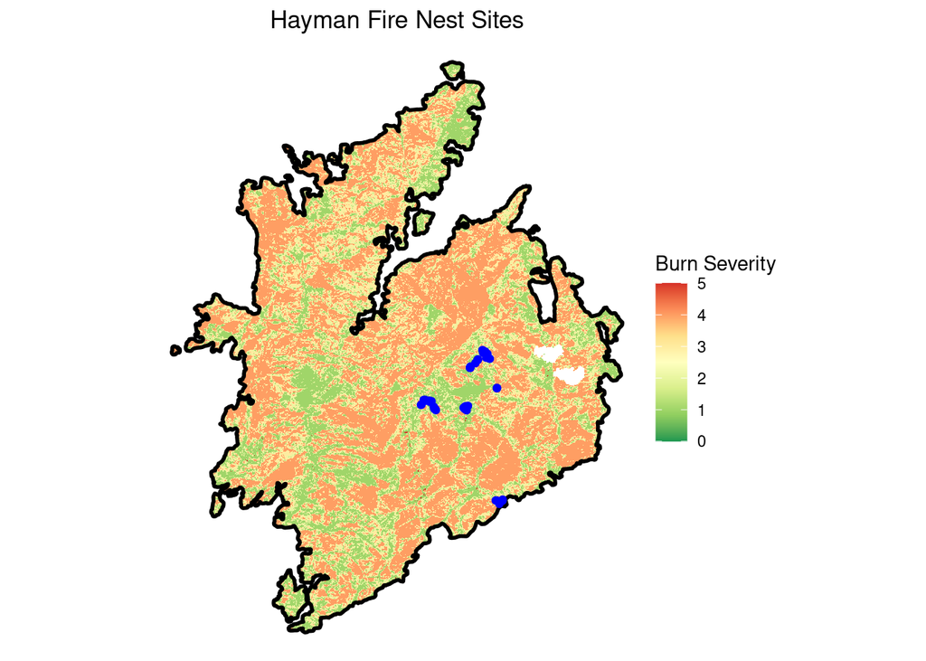

Flammulated Owl nests sampled in the Hayman Fire burn scar (blue) plotted over Normalized Burn Ratios (NBR) depicting burn severity.

```r
# Read in nest tree data
nest_dat <- read.csv("../data/nest_trees.csv")

# Plot nest trees over Hayman burn map
sev_bound_plot +
  geom_point(data = nest_dat, mapping = aes(x = x_coord, y = y_coord), color = "blue") +
  ggtitle("Hayman Fire Nest Sites") +
  theme_void() +
  theme(plot.title = element_text(hjust = 0.5))
```

# Prey Delivery Rates by Sex

First, we compared average prey delivery rates for males and females at all study sties at fifteen minute intervals throughout the night.

### Read in Data

Load prey delivery data.

```r
pdOriginal <- read.csv("../data/pd_main.csv")

#rename the first column, which imported with a special character
names(pdOriginal)[1] <- "nest"
```

Filter to only include M and F (remove ‘unknown’ and ‘total’), separate ‘nest’ column into ‘study_site’ and ‘territory.’

```r
pdMF <- pdOriginal %>%
  separate(col = nest, into = c("study_site", "territory"), sep = 1, remove = TRUE) %>%
  filter(sex == "M" | sex == "F")
```

Check structure of data.

```r
pd_str <- str(pdMF)
```

```
## 'data.frame':    1299 obs. of  55 variables:
##  $ study_site       : chr  "A" "A" "B" "C" ...
##  $ territory        : chr  "29_2007" "29_2007" "7_2005" "S1_1_2005" ...
##  $ year             : int  2007 2007 2005 2005 2005 2005 2006 2006 2014 2004 ...
##  $ obs_date         : Factor w/ 329 levels "","5/30/2006",..: 160 160 35 184 172 69 168 168 163 3 ...
##  $ clutch_size      : Factor w/ 8 levels "","-","?","1",..: 5 5 1 1 1 1 5 5 5 6 ...
##  $ brood_size       : Factor w/ 13 levels "","-","?",">=2",..: 9 9 1 1 1 1 9 9 9 11 ...
##  $ num_fledged      : Factor w/ 11 levels "","-","≥1","≥2",..: 7 7 1 1 1 1 5 5 7 8 ...
##  $ incubation_start : Factor w/ 143 levels "","?","5/13/2012",..: 126 126 1 1 1 1 125 125 112 57 ...
##  $ julian_incubation: int  157 157 NA NA NA NA 157 157 155 151 ...
##  $ nest_age         : Factor w/ 56 levels "","0","1","10",..: 3 3 3 3 3 3 3 3 3 15 ...
##  $ sunset           : int  2021 2021 NA 2025 2023 2020 2023 2023 2026 2019 ...
##  $ sex              : Factor w/ 9 levels "All","F","H",..: 4 2 2 2 2 2 4 2 4 4 ...
##  $ t15              : int  NA NA 0 NA NA NA NA NA 2 NA ...
##  $ t30              : int  NA NA 0 NA NA NA NA NA NA 0 ...
```

[output cut: 41 more lines]

```r
unique(pdMF$t180) #at least one cell has an asterisk after the value
```

```
##  [1] 1  0     4  4* 2  9  10 3  5
## Levels:  0 1 10 12 2 3 4 4* 5 6 9
```

```r
unique(pdMF$t225) #same here
```

```
## [1] 1  0     6* 3  2  8  11 7
## Levels:  0 1 11 2 3 5 6* 7 8
```

```r
unique(pdMF$nest_age) #"pred" and "" can be converted to NA
```

```
##  [1] 1    2    3    4    5    6    7    8    9    10   11   12   13   14   15
## [16] 16   17   18   19   20   21   22   23   24   25   26   27   28   29   30
## [31] 31   32   33   34   35   36   37   38   39   40   41   42   43   44   45
## [46] 46   47   48   49   50   51   53   100  0    pred
## 56 Levels:  0 1 10 100 11 12 13 14 15 16 17 18 19 2 20 21 22 23 24 25 26 ... pred
```

Fix structure by removing asterisks and converting to integer class. NAs will be generated by coercion, eliminating any blank cells ("“) and cells containing”pred" (indicating the nest was predated before the nest age could be confirmed).

```r
#remove asterisks
pdClean <- pdMF %>%
  mutate(t180 = gsub("\\*", "", t180)) %>%
  mutate(t225 = gsub("\\*", "", t225))


#change these columns to numeric
pdClean$t180 <- as.integer(pdClean$t180)
pdClean$t225 <- as.integer(pdClean$t225)
pdClean$nest_age <- as.integer(pdClean$nest_age)
```

### Organize Data

Data was separated by sex (M vs. F) and by incubation vs. nestling stage. Nestling period is defined as nest_age >= 22 days. If nest age was not indicated in original dataset, field notes were used to determine whether nest was in incubation (all eggs) or nestling (at least one nestling) stage. For these records, the following values were manually input: nest_age = 0 for incubation or nest_age = 100 for nestling, so that this data could be easily separated from known nest age. If it was later determined that nest had been predated before observation, “pred” was entered. If the nest stage could not be determined, it was left blank.“pred” and "" values were converted to NA earlier when this column was converted to numeric.

```r
# Create independent dfs for M (nestling and incubation stage) and F (nestling and incubation stage).

pdStage_sex <- pdClean %>%
  dplyr::select(sex, nest_age, t15:t240) %>% #select relevant columns
  mutate(
    stage =
      ifelse(nest_age < 22, "incubation", "nestling")) %>% #add column for 'stage'
  drop_na(stage) #get rid of any rows blank values here, as they can't be used for analysis

#change column names to remove "t" in front of time interval
colnames(pdStage_sex) <- c("sex", "nest_age", "15", "30", "45", "60", "75", "90",
                           "105", "120", "135", "150", "165", "180", "195", "210",
                           "225", "240", "stage")

#create independent dfs for each study site and stage
pdM_inc <- pdStage_sex %>%
  filter(sex =="M", stage == "incubation") %>%
  dplyr::select('15':'240')

pdM_nest <- pdStage_sex %>%
  filter(sex =="M", stage == "nestling") %>%
  dplyr::select('15':'240')

pdF_inc <- pdStage_sex %>%
  filter(sex =="F", stage == "incubation") %>%
  dplyr::select('15':'240')

pdF_nest <- pdStage_sex %>%
  filter(sex =="F", stage == "nestling") %>%
  dplyr::select('15':'240')
```

### Mean PD tables

Create four stand-alone data.frames, one for M (incubation), one for M (nestling), one for F (incubation), and one for F (nestling). These will be used for t-tests.

```r
meanM_inc <- data.frame(
  time = as.numeric(colnames(pdM_inc)),
  M_incubation = colMeans(pdM_inc, na.rm = TRUE))

meanM_nest <- data.frame(
  time = as.numeric(colnames(pdM_nest)),
  M_nestling = colMeans(pdM_nest, na.rm = TRUE))

meanF_inc <- data.frame(
  time = as.numeric(colnames(pdF_inc)),
  F_incubation = colMeans(pdF_inc, na.rm = TRUE))

meanF_nest <- data.frame(
  time = as.numeric(colnames(pdF_nest)),
  F_nestling = colMeans(pdF_nest, na.rm = TRUE))
```

### Calculate confidence intervals

Apply getCI function across data.frames for each sex and stage.

```r
ciM_inc <- apply(pdM_inc, 2, FUN = getCI)
ciM_nest <- apply(pdM_nest, 2, FUN = getCI)
ciF_inc <- apply(pdF_inc, 2, FUN = getCI)
ciF_nest <- apply(pdF_nest, 2, FUN = getCI)
```

```r
ciInc_sex <- data.frame(
    sex = c(rep("M", nrow(meanM_inc)), rep("F", nrow(meanF_inc))),
    mean = c(colMeans(pdM_inc, na.rm = TRUE), colMeans(pdF_inc, na.rm = TRUE)),
    ci_l = c(ciM_inc[1,], ciF_inc[1,]),
    ci_h = c(ciM_inc[2,], ciF_inc[2,]),
    time = c(as.numeric(rownames(meanM_inc)), as.numeric(rownames(meanF_inc))),
    stage = "Incubation")


ciNest_sex <- data.frame(
    sex = c(rep("M", nrow(meanM_nest)), rep("F", nrow(meanF_nest))),
    mean = c(colMeans(pdM_nest, na.rm = TRUE), colMeans(pdF_nest, na.rm = TRUE)),
    ci_l = c(ciM_nest[1,], ciF_nest[1,]),
    ci_h = c(ciM_nest[2,], ciF_nest[2,]),
    time = c(as.numeric(rownames(meanM_nest)), as.numeric(rownames(meanF_nest))),
    stage = "Nestling")
```

### Test for Difference

```r
# Store results of testNormality in new df
normality_sex <- data.frame(
  M_inc = testNormality(pdM_inc, 2),
  M_nest = testNormality(pdM_nest, 2),
  F_nest = testNormality(pdF_nest, 2)
  )

# Test if any values are not significant
any(normality_sex >= 0.05)
```

```
## [1] FALSE
```

All vectors in each list are significantly different from null hypothesis of Shapiro-Wilk normality test, meaning that no vector is normally distributed. Therefore, we use the unpaired two-sample Wilcoxon test to compare median values of M and F prey deliveries during each time interval, for incubation and nestling stages.

```r
# Incubation Stage
wilcox_inc_sex <- testWilcox(pdM_inc, pdF_inc)
print(wilcox_inc_sex)
```

```
##          values ind
## 1  1.019974e-06  15
## 2  1.842053e-13  30
## 3  8.812928e-17  45
## 4  4.876663e-23  60
## 5  4.979458e-17  75
## 6  1.416015e-11  90
## 7  2.042524e-11 105
## 8  1.146429e-08 120
## 9  6.929846e-06 135
## 10 1.262014e-04 150
## 11 8.600343e-04 165
## 12 5.766232e-05 180
## 13 4.327965e-03 195
## 14 1.005653e-02 210
## 15 1.204784e-01 225
## 16 3.815739e-01 240
```

```r
any(wilcox_inc_sex$values <= 0.05) #test if any p.values are sig diff
```

```
## [1] TRUE
```

```r
all(wilcox_inc_sex$values <= 0.05) #test if all p.values are sig diff
```

```
## [1] FALSE
```

```r
dplyr::filter(wilcox_inc_sex, values <= 0.05) #print which rows have sig diff p.value
```

```
##          values ind
## 1  1.019974e-06  15
## 2  1.842053e-13  30
## 3  8.812928e-17  45
## 4  4.876663e-23  60
## 5  4.979458e-17  75
## 6  1.416015e-11  90
## 7  2.042524e-11 105
## 8  1.146429e-08 120
## 9  6.929846e-06 135
## 10 1.262014e-04 150
## 11 8.600343e-04 165
## 12 5.766232e-05 180
## 13 4.327965e-03 195
## 14 1.005653e-02 210
```

```r
# Nestling Stage
wilcox_nest_sex <- testWilcox(pdM_nest, pdF_nest)
print(wilcox_nest_sex)
```

```
##          values ind
## 1  6.653744e-05  15
## 2  5.385296e-11  30
## 3  8.915504e-08  45
## 4  6.881521e-07  60
## 5  1.758982e-13  75
## 6  2.404649e-10  90
## 7  3.977980e-06 105
## 8  2.672459e-06 120
## 9  9.038698e-09 135
## 10 1.039497e-04 150
## 11 2.751843e-05 165
## 12 3.539645e-06 180
## 13 2.332547e-02 195
## 14 2.006606e-04 210
## 15 2.127009e-04 225
## 16 2.171260e-04 240
```

```r
any(wilcox_nest_sex$values <= 0.05) #test if any p.values are sig diff
```

```
## [1] TRUE
```

```r
all(wilcox_nest_sex$values <= 0.05) #test if all p.values are sig diff
```

```
## [1] TRUE
```

From the Wilcoxon tests, we see that all median time intervals during the nestling stage are significantly different between males and females. However, during the incubation stage, median prey delivery rates at time = 2255 and time = 240 are not significantly different between males and females.

### Plot

Incubation (including star indicating non-significant Wilcoxon test at t = 225 and t = 240):

```r
plotInc_sex <- ggplot(data = ciInc_sex) +
  geom_point(aes(x = time, y = mean, color = sex, group = sex),
             position = position_dodge(width=0.75)) +
  geom_errorbar(aes(x=time, ymax = ci_h, ymin=ci_l, color = sex,
                    group = sex),
                position = position_dodge(width=0.75)) +
  labs(x = "Time After Sunset (minutes)", y = "Mean Prey Deliveries",
       title = "Incubation", color = "Sex") +
  theme_minimal() +
  theme(plot.title = element_text(hjust = 0.5)) +
  geom_point(aes(x = 225, y = 3.0), shape = 8, stroke = 0.1) +
  geom_point(aes(x = 240, y = 2.5), shape = 8, stroke = 0.1)
```

Nestling:

```r
plotNest_sex <- ggplot(data = ciNest_sex) +
  geom_point(aes(x = time, y = mean, color = sex, group = sex),
             position = position_dodge(width=0.75)) +
  geom_errorbar(aes(x=time, ymax = ci_h, ymin=ci_l, color = sex,
                    group = sex),
                position = position_dodge(width=0.75)) +
  labs(x = "Time After Sunset (minutes)", y = "Mean Prey Deliveries",
       title = "Nestling", color = "Sex") +
  theme_minimal() +
  theme(plot.title = element_text(hjust = 0.5))
```

The final plot compares both incubation and nestling stages.

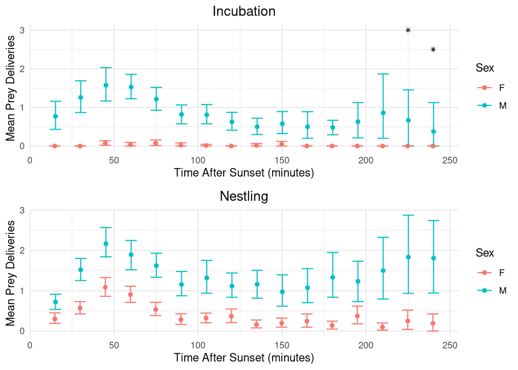

Mean prey deliveries during the incubation stage (top) and nestling stage (bottom). Males are shown in bue and females in red. Stars indicate non-significant differences in medians based on unpaired two-sample Wilcoxon tests.

```r
grid.arrange(plotInc_sex, plotNest_sex)
```

# Prey Delivery Rates by Site

The original spreadsheet contains prey delivery data from two other studies that were not considered in this analysis. Therefore, they were filtered out, and “B” (MGSA) and “C” (HFSA) were preserved for the analysis. Females were also excluded because here was not sufficient data for reliable analysis.

```r
pdHM <- pdClean %>%
  filter(study_site == "B" | study_site == "C", sex == "M")
```

### Organize Data

Data was separated by study site (HFSA vs. MGSA) and by incubation vs. nestling stage. Since the last observation for HFSA is at time = 240, we’ll end the first data.frame there.

Then, create data.frames for each study site and stage. End incubation data.frames at t = 180 and nestling data.frames at t = 240 because this is the maximum time when there is data for both sites.

```r
#create independet dfs for HFSA (nestling and incubation stage) and MGSA (nestling and incubation state).

#select relevant columns, add column for stage, rename study sites, drop NAs
pdStage_site <- pdClean %>%
  dplyr::select(study_site, nest_age, t15:t240) %>%
  mutate(
    stage =
      ifelse(nest_age < 22, "incubation", "nestling"),
    study_site =
      ifelse(study_site == "B", "MGSA", "HFSA")) %>%
  drop_na(stage)

#change column names to remove "t" in front of time interval
colnames(pdStage_site) <- c("study_site", "nest_age", "15", "30", "45", "60",
                            "75", "90", "105", "120", "135", "150", "165", "180",
                            "195", "210", "225", "240", "stage")

#create independent dfs for each study site and stage
pdHFSA_inc <- pdStage_site %>%
  filter(study_site =="HFSA", stage == "incubation") %>%
  dplyr::select('15':'180')

pdHFSA_nest <- pdStage_site %>%
  filter(study_site =="HFSA", stage == "nestling") %>%
  dplyr::select('15':'240')

pdMGSA_inc <- pdStage_site %>%
  filter(study_site =="MGSA", stage == "incubation") %>%
  dplyr::select('15':'180')

pdMGSA_nest <- pdStage_site %>%
  filter(study_site =="MGSA", stage == "nestling") %>%
  dplyr::select('15':'240')
```

### Mean PD tables

Create four stand-alone data.frames, one for HFSA (incubation), one for HFSA (nestling), one for MGSA (incubation), and one for MGSA (nestling).

```r
meanHFSA_inc <- data.frame(
  time = as.numeric(colnames(pdHFSA_inc)),
  HFSA_incubation = colMeans(pdHFSA_inc, na.rm = TRUE))

meanHFSA_nest <- data.frame(
  time = as.numeric(colnames(pdHFSA_nest)),
  HFSA_nestling = colMeans(pdHFSA_nest, na.rm = TRUE))

meanMGSA_inc <- data.frame(
  time = as.numeric(colnames(pdMGSA_inc)),
  MGSA_incubation = colMeans(pdMGSA_inc, na.rm = TRUE))

meanMGSA_nest <- data.frame(
  time = as.numeric(colnames(pdMGSA_nest)),
  MGSA_nestling = colMeans(pdMGSA_nest, na.rm = TRUE))
```

### Calculate confidence intervals

Apply getCI across each data.frame, taking each time interval as vector.

```r
ciHFSA_inc <- apply(pdHFSA_inc, 2, FUN = getCI)
ciHFSA_nest <- apply(pdHFSA_nest, 2, FUN = getCI)
ciMGSA_inc <- apply(pdMGSA_inc, 2, FUN = getCI)
ciMGSA_nest <- apply(pdMGSA_nest, 2, FUN = getCI)
```

Add CIs to a data.frame.

```r
ciInc <- data.frame(
    study_area = c(rep("HFSA", nrow(meanHFSA_inc)), rep("MGSA", nrow(meanMGSA_inc))),
    mean = c(colMeans(pdHFSA_inc, na.rm = TRUE), colMeans(pdMGSA_inc, na.rm = TRUE)),
    ci_l = c(ciHFSA_inc[1,], ciMGSA_inc[1,]),
    ci_h = c(ciHFSA_inc[2,], ciMGSA_inc[2,]),
    time = c(as.numeric(rownames(meanHFSA_inc)), as.numeric(rownames(meanMGSA_inc))),
    stage = "Incubation")


ciNest <- data.frame(
    study_area = c(rep("HFSA", nrow(meanHFSA_nest)), rep("MGSA", nrow(meanMGSA_nest))),
    mean = c(colMeans(pdHFSA_nest, na.rm = TRUE), colMeans(pdMGSA_nest, na.rm = TRUE)),
    ci_l = c(ciHFSA_nest[1,], ciMGSA_nest[1,]),
    ci_h = c(ciHFSA_nest[2,], ciMGSA_nest[2,]),
    time = c(as.numeric(rownames(meanHFSA_nest)), as.numeric(rownames(meanMGSA_nest))),
    stage = "Nestling")
```

### Test for Difference

Test for normality for each time interval in pdMGSA_inc, pdMGSA_nest, pdHFSA_inc, and pdHFSA_nest.

```r
# Store results of testNormality in new df
normality_site <- list(
  MGSA_inc = testNormality(pdMGSA_inc, 2),
  MGSA_nest = testNormality(pdMGSA_nest, 2),
  HFSA_inc = testNormality(pdHFSA_inc, 2),
  HFSA_nest = testNormality(pdHFSA_nest, 2))

# Test if any values are not significant
sapply(normality_site, FUN = function(x){any(x >= 0.05)})
```

```
##  MGSA_inc MGSA_nest  HFSA_inc HFSA_nest
##     FALSE     FALSE     FALSE     FALSE
```

All vectors in each list are significantly different from null hypothesis of Shapiro-Wilk normality test, meaning that no vector is normally distributed. Therefore, we use the unpaired two-sample Wilcoxon test to compare median values for each time interval in MGSA and HFSA, for incubation and nestling stages.

```r
# Incubation Stage
wilcox_inc_site <- testWilcox(pdMGSA_inc, pdHFSA_inc)
print(wilcox_inc_site)
```

```
##       values ind
## 1  0.9242557  15
## 2  0.8559074  30
## 3  0.0509752  45
## 4  0.3946968  60
## 5  0.2241870  75
## 6  0.2673633  90
## 7  0.6397543 105
## 8  0.9371807 120
## 9  0.8637855 135
## 10 0.1421301 150
## 11 0.3553358 165
## 12 0.8206028 180
```

```r
any(wilcox_inc_site$values <= 0.05) #test if any p.values are sig dif
```

```
## [1] FALSE
```

```r
all(wilcox_inc_site$values > 0.05) #test if all p.values are not significant
```

```
## [1] TRUE
```

```r
# Nestling Stage
wilcox_nest_site <- testWilcox(pdMGSA_nest, pdHFSA_nest)
print(wilcox_inc_site)
```

```
##       values ind
## 1  0.9242557  15
## 2  0.8559074  30
## 3  0.0509752  45
## 4  0.3946968  60
## 5  0.2241870  75
## 6  0.2673633  90
## 7  0.6397543 105
## 8  0.9371807 120
## 9  0.8637855 135
## 10 0.1421301 150
## 11 0.3553358 165
## 12 0.8206028 180
```

```r
any(wilcox_nest_site$values <= 0.05) #test if any p.values are sig diff
```

```
## [1] TRUE
```

```r
dplyr::filter(wilcox_nest_site, values <= 0.05) #print which row has sig diff p.value
```

```
##       values ind
## 1 0.04904887 165
```

From the Wilcoxon tests, we see that no median time intervals during the incubation stage are different between MGSA and HFSA. However, during the nestling stage, median prey delivery rates at time = 165 are significantly different between MGSA and HFSA.

### Plot

Mean prey deliveries throughout night in incubation stage:

```r
plotInc_site <- ggplot(data = ciInc) +
  geom_point(aes(x = time, y = mean, color = study_area, group = study_area),
             position = position_dodge(width=0.75)) +
  geom_errorbar(aes(x=time, ymax = ci_h, ymin=ci_l, color = study_area,
                    group = study_area),
                position = position_dodge(width=0.75)) +
  labs(x = "Time After Sunset (minutes)", y = "Mean Prey Deliveries",
       title = "Incubation", color = "Study Area") +
  theme_minimal() +
  theme(plot.title = element_text(hjust = 0.5))
```

Mean prey deliveries throughout night in the nestling stage (including star indicating significant Wilcoxon test at t = 165):

```r
plotNest_site <- ggplot(data = ciNest) +
  geom_point(aes(x = time, y = mean, color = study_area, group = study_area),
             position = position_dodge(width=0.75)) +
  geom_errorbar(aes(x=time, ymax = ci_h, ymin=ci_l, color = study_area,
                    group = study_area),
                position = position_dodge(width=0.75)) +
  labs(x = "Time After Sunset (minutes)", y = "Mean Prey Deliveries",
       title = "Nestling", color = "Study Area") +
  theme_minimal() +
  theme(plot.title = element_text(hjust = 0.5)) +
  geom_point(aes(x = 165, y = 2.0), shape = 8, stroke = 0.1)
```

The final plot compares both incubation and nestling stages.

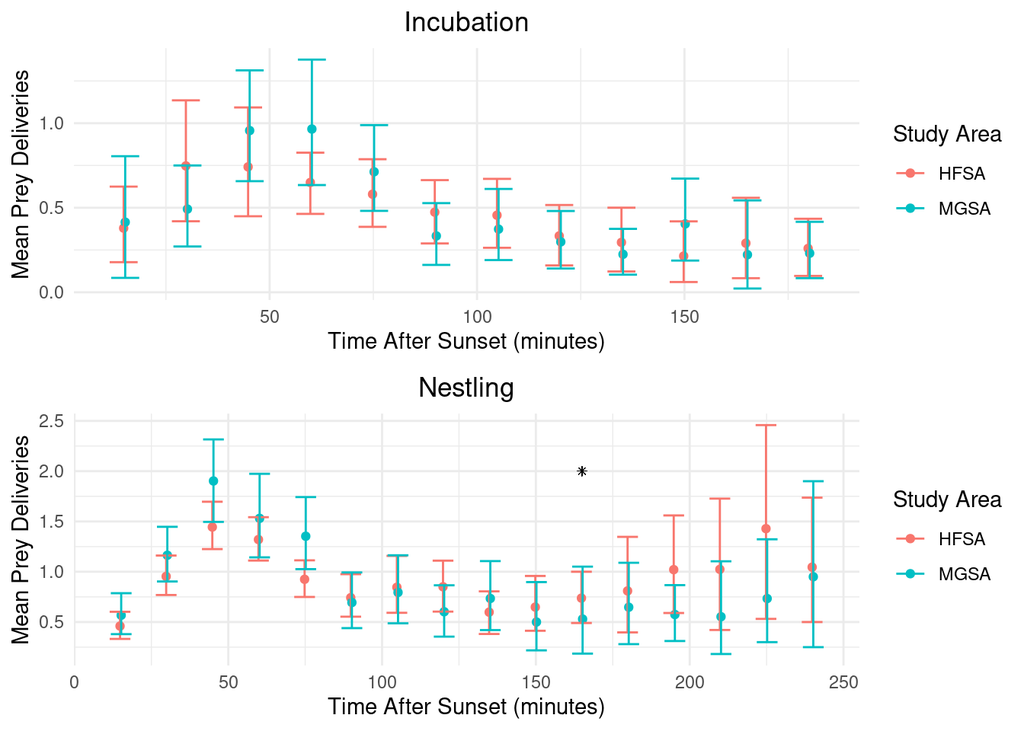

Mean prey deliveries during the incubation stage (top) and nestling stage (bottom). Missouri Gulch Study Area (MGSA) is shown in bue and Hayman Fire Study Area (HFSA) in red. Stars indicate significant differences in medians based on unpaired two-sample Wilcoxon tests.

```r
grid.arrange(plotInc_site, plotNest_site)
```

# Discussion

Almost no mean prey delivery rates were significantly different between the HFSA and MGSA, with the exception of time = 165 during the nestling stage (Figure 3). However, his does not appear to have biological significance and would likely become insignificant with an increased sample size.

This study has shown that across study site, males are the primary nest provisioners, with females delivering small amounts of prey during the nestling season. Decreased habitat quality in the Hayman Fire scar may be putting more pressure on foraging males, who may have to travel further to locate adequate foraging sites, thus increasing energy demands. Although habitat quality continues to deteriorate, Flammulated Owls still return to the HFSA each year to breed. The specialized natural of their foraging habitat, combined with the males’ inability to adapt nest provisioning behavior following large-scale disturbance, may be contributing to overall decreased annual survivorship for male Flammulated Owls breeding in the Hayman Fire burn area.

# References

Fornwalt, P. J., Huckaby, L. S., Alton, S. K., Kaufmann, M. R., Brown, P. M., & Cheng, A. S. (2016). Did the 2002 hayman fire, colorado, usa, burn with uncharacteristic severity? *Fire Ecology*, *12*(3), 117–132.

Graham, R. T. (2003). *Hayman fire case study*. US Department of Agriculture, Forest Service, Rocky Mountain Research Station.

Griffis, K. L., Crawford, J. A., Wagner, M. R., & Moir, W. (2001). Understory response to management treatments in northern arizona ponderosa pine forests. *Forest Ecology and Management*, *146*(1-3), 239–245.

Linkhart, B., & McCallum, D. (2013). Flammulated owl (psiloscops flammeolus). *The Birds of North America (PG Rodewald, Editor). Cornell Lab of Ornithology, Ithaca, NY, USA. Https://Birdsna. Org/Species-Account/Bna/Species/Flaowl*.

Nappi, A., Drapeau, P., Saint-Germain, M., & Angers, V. A. (2010). Effect of fire severity on long-term occupancy of burned boreal conifer forests by saproxylic insects and wood-foraging birds. *International Journal of Wildland Fire*, *19*(4), 500–511.

Reynolds, R. T., & Linkhart, B. D. (1992). Flammulated owls in ponderosa pine: Evidence of preference for old growth. *MR Kaufman, Wh Moir, and Rl Bassett, Technical Coordinators. Proceedings of the Workshop on Old-Growth in the Southwest and Rocky Mountain Region. Portal, Arizona, Usa*, 166–169.

Veblen, T., Kitzberger, T., & Donnegan, J. (2000). Climatic and human influences on fire regimes in ponderosa pine forests in the colorado front range. *Ecological Applications*, *10*(4), 1178–1195.

Zárybnická, M., Sedláček, O., & Korpimäki, E. (2009). Do tengmalm’s owls alter parental feeding effort under varying conditions of main prey availability? *Journal of Ornithology*, *150*(1), 231–237.